# Stats 199 Research

```r
summary(res.ca)
```

```
##
## Call:
## CA(X = children, row.sup = 15:18, col.sup = 6:8)
##
## The chi square of independence between the two variables is equal to 98.80159 (p-value =  9.748064e-05 ).
##
## Eigenvalues
##                        Dim.1   Dim.2   Dim.3   Dim.4
## Variance               0.035   0.013   0.007   0.006
## % of var.             57.043  21.132  11.764  10.061
## Cumulative % of var.  57.043  78.175  89.939 100.000
##
## Rows (the 10 first)
##                       Iner*1000    Dim.1    ctr   cos2    Dim.2    ctr
## money               |     3.759 | -0.115  4.550  0.428 |  0.020  0.371
## future              |     8.690 |  0.176 17.567  0.716 | -0.098 14.587
## unemployment        |     9.151 | -0.212 22.616  0.875 | -0.071  6.779
## circumstances       |     3.804 |  0.401  6.274  0.584 |  0.331 11.544
## hard                |     1.199 | -0.250  2.994  0.884 |  0.068  0.592
## economic            |     8.787 |  0.354 12.005  0.484 |  0.321 26.604
## egoism              |     3.287 |  0.060  0.681  0.073 | -0.026  0.338
## employment          |     5.648 | -0.137  2.621  0.164 |  0.215 17.555
## finances            |     3.576 | -0.237  2.790  0.276 | -0.206  5.690
## war                 |     1.025 |  0.217  2.169  0.749 | -0.075  0.694
##                       cos2    Dim.3    ctr   cos2
## money                0.013 |  0.101 16.884  0.328 |
## future               0.220 | -0.053  7.568  0.064 |
## unemployment         0.097 | -0.004  0.046  0.000 |
## circumstances        0.398 | -0.016  0.046  0.001 |
## hard                 0.065 |  0.060  0.845  0.051 |
## economic             0.397 |  0.084  3.280  0.027 |
## egoism               0.013 |  0.179 29.496  0.655 |
## employment           0.408 | -0.213 30.815  0.398 |
## finances             0.209 | -0.044  0.469  0.010 |
## war                  0.089 | -0.098  2.139  0.152 |
##
## Columns
##                       Iner*1000    Dim.1    ctr   cos2    Dim.2    ctr
## unqualified         |    13.146 | -0.209 25.110  0.676 | -0.081 10.082
## cep                 |    10.044 | -0.139 18.297  0.645 |  0.056  8.079
## bepc                |     7.670 |  0.109  6.758  0.312 | -0.028  1.251
## high_school_diploma |    17.732 |  0.274 37.976  0.758 | -0.121 20.099
## university          |    13.468 |  0.231 11.859  0.312 |  0.318 60.488
##                       cos2    Dim.3    ctr   cos2
## unqualified          0.101 |  0.073 14.659  0.081 |
## cep                  0.105 | -0.018  1.520  0.011 |
## bepc                 0.021 | -0.147 59.874  0.570 |
## high_school_diploma  0.149 |  0.077 14.407  0.059 |
## university           0.589 |  0.094  9.540  0.052 |
##
## Supplementary rows
##                       Dim.1  cos2   Dim.2  cos2   Dim.3  cos2
## comfort             | 0.210 0.069 | 0.703 0.775 | 0.071 0.008 |
## disagreement        | 0.146 0.131 | 0.119 0.087 | 0.171 0.180 |
## world               | 0.523 0.876 | 0.143 0.065 | 0.084 0.023 |
## to_live             | 0.308 0.139 | 0.502 0.369 | 0.521 0.397 |
##
## Supplementary columns
##                        Dim.1   cos2    Dim.2   cos2    Dim.3   cos2
## thirty              |  0.105  0.138 | -0.060  0.044 | -0.103  0.132 |
## fifty               | -0.017  0.011 |  0.049  0.090 | -0.016  0.009 |
## more_fifty          | -0.177  0.286 | -0.048  0.021 |  0.101  0.093 |
```

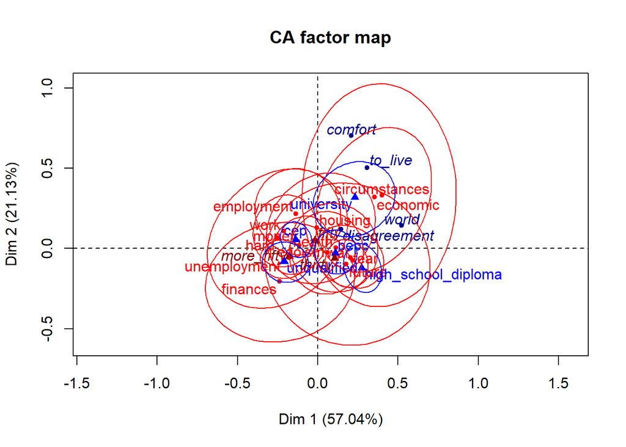

```r
## Ellipses for all the active elements
ellipseCA(res.ca)
```

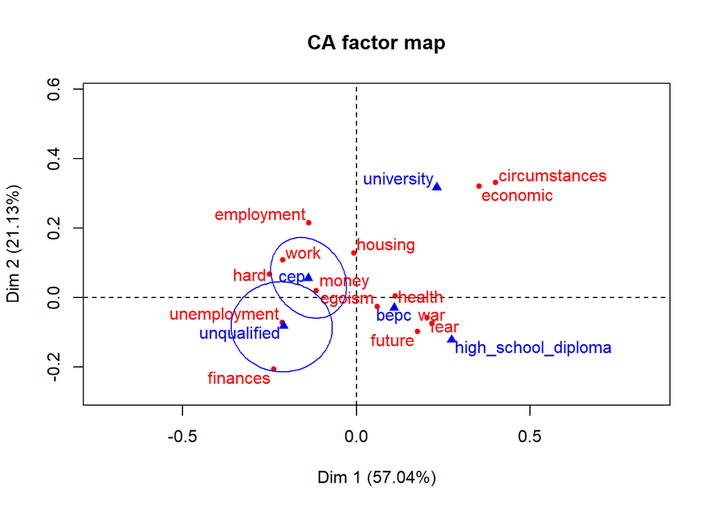

```r
## Ellipses around some columns only
ellipseCA(res.ca,ellipse="col",col.col.ell=c(rep("blue",2),rep("transparent",3)),
     invisible=c("row.sup","col.sup"))
```

```r
#Multiple CA with CA package
#mjca

data("wg93")
mjca(wg93[,1:4])
```

```
##
##  Eigenvalues:
##            1        2       3        4       5        6
## Value      0.076455 0.05822 0.009197 0.00567 0.001172 7e-06
## Percentage 44.91%   34.2%   5.4%     3.33%   0.69%    0%
##
##
##  Columns:
##               A:1      A:2       A:3       A:4       A:5       B:1
## Mass     0.034156 0.092423  0.058553  0.051091  0.013777  0.020379
## ChiDist  1.343394 0.676433  0.947274  1.049164  2.214898  1.856041
## Inertia  0.061642 0.042289  0.052542  0.056238  0.067588  0.070203
## Dim. 1   1.836627 0.546240 -0.446797 -1.165903 -1.995217  2.924321
## Dim. 2  -0.727459 0.284443  1.199439 -0.736782 -2.470026 -1.370078
##              B:2      B:3       B:4       B:5       C:1      C:2       C:3
## Mass    0.049943 0.058840  0.080654  0.040184  0.043628 0.090700  0.056544
## ChiDist 1.034203 0.933288  0.760011  1.294006  1.241063 0.688137  0.977789
## Inertia 0.053417 0.051252  0.046587  0.067286  0.067197 0.042950  0.054060
## Dim. 1  0.641516 0.346050 -0.714126 -1.353725  2.157782 0.246828 -0.618996
## Dim. 2  0.666938 0.963918  0.280071 -2.107677 -0.908553 0.591611  1.044412
##               C:4       C:5       D:1       D:2       D:3       D:4
## Mass     0.044202  0.014925  0.017222  0.066590  0.057979  0.064868
## ChiDist  1.148345  2.132827  1.915937  0.843092  0.962007  0.860714
## Inertia  0.058289  0.067895  0.063217  0.047333  0.053657  0.048056
## Dim. 1  -1.348858 -1.467582  1.203782 -0.221151 -0.384656 -0.221635
## Dim. 2  -0.634647 -3.016588 -1.821975  0.006935  1.158694  0.210513
##               D:5
## Mass     0.043341
## ChiDist  1.136559
## Inertia  0.055986
## Dim. 1   0.707750
## Dim. 2  -1.151804
```

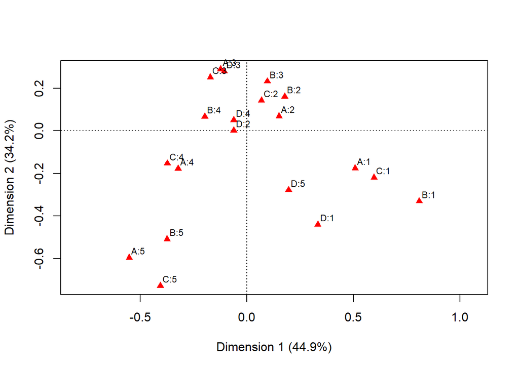

```r
plot(mjca(wg93[,1:4]))
```

```r
data(UCBAdmissions)
mjca(UCBAdmissions)
```

```
##
##  Eigenvalues:
##            1        2        3  4  5
## Value      0.114945 0.005694 0  0  0
## Percentage 80.47%   3.99%    0% 0% 0%
##
##
##  Columns:
##         Admit:Admitted Admit:Rejected Gender:Female Gender:Male   Dept:A
## Mass          0.129253       0.204080      0.135145    0.198188 0.068714
## ChiDist       0.792214       0.501745      0.783694    0.534403 1.221480
## Inertia       0.081120       0.051377      0.083003    0.056600 0.102522
## Dim. 1        1.075594      -0.681222     -1.175453    0.801545 1.508902
## Dim. 2        0.974981      -0.617499      0.786218   -0.536124 0.167342
##            Dept:B    Dept:C    Dept:D    Dept:E    Dept:F
## Mass     0.043084  0.067609  0.058330  0.043011  0.052585
## ChiDist  1.584797  1.179839  1.257459  1.541085  1.390552
## Inertia  0.108210  0.094114  0.092231  0.102148  0.101680
## Dim. 1   1.691541 -0.797163 -0.323064 -1.132444 -1.048107
## Dim. 2  -0.595723  1.717196  0.088564  0.908371 -2.779621
```

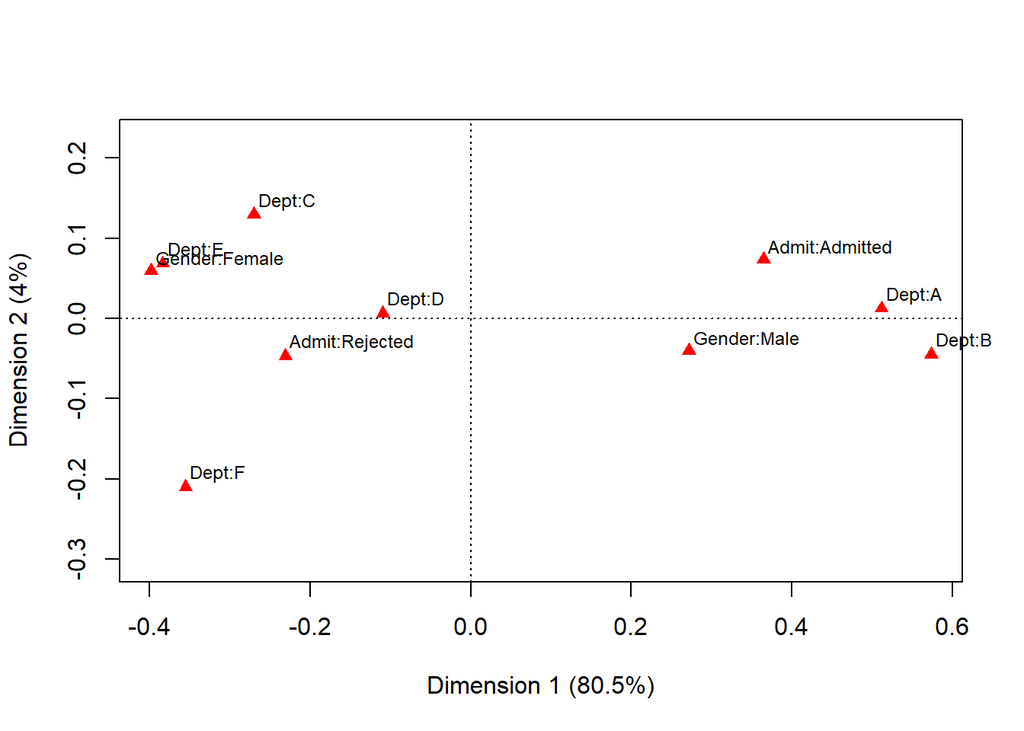

```r
plot(mjca(UCBAdmissions))
```

```r
#Package By Nenadine and Greenacre
# library(ca)
#
# #EXAMPLE ###############
# #Where A and B are categorical factors
# # Correspondence Analysis
# library(ca)
 # mytable <- with(mydata, table(A,B)) # create a 2 way table
 # prop.table(mytable, 1) # row percentages
 # prop.table(mytable, 2) # column percentages
 # fit <- ca(mytable)
 # print(fit) # basic results
 # summary(fit) # extended results
 # plot(fit) # symmetric map
 # plot(fit, mass = TRUE, contrib = "absolute", map =
 #   "rowgreen", arrows = c(FALSE, TRUE)) # asymmetric map

#############################
```

**Questions:**

Focusing on session 2.1

Maually cleaning data via excel

Starting with the session2.1 file only first. Questions before merging: What type of merge? What to do with the multiple ID’s appearing, the “Total” column, and the percentage column seems incorrect as well….

If we group the data by researchID: Do we have to relabel the variables by session # as well to keep track of which questions are asked?

dplyr: we can do group_by(Question) to see how students across the board fared on particular questions

Reading in the data

The way the data was collected: Were questions not asked for every session the class met? How many answer choices per question? Is it the same number of choices per question or does it vary? I saw some ‘E’ responses…

How does the ‘Total’ column work? Only seems to be recording a 0 or a 2, regardless of the number of questions answered.

I wasn’t too sure for the multiple ID’s appearing… So I manually began to remove them for cleaning.

case of ca62 researchID: 3 rows, 2 blanks, 1 3 answers, rest blank? Removed the 2 blanks rows, kept the 3 answers, rest blank row.

Removed the 3 NA values for the researchID’s in the last 3 rows.

How many individual students were registered to take this class? Were any added on after the start? This could help us answer these questions we have about the data.

Why are some question numbers skipped?

47 unique ID’s

**Insights from the histograms** This graph reveals the most difficult answer to be Question 2. What seems strange is that upon answering the questions a 2nd or 3rd time, the students seem to be getting a worse score(e.g. Questions 2 and 4).

Upon first glance, it seems that even when there is no correct answer(No Key Questions), the students tend to all select the same answer.

```
## 'data.frame':    752 obs. of  5 variables:
##  $ Total     : int  2 2 2 2 2 2 2 2 2 0 ...
##  $ Percentage: Factor w/ 2 levels "0%","100%": 2 2 2 2 2 2 2 2 2 1 ...
##  $ researchID: Factor w/ 47 levels "ab70","as160",..: 1 2 3 4 5 6 7 8 9 10 ...
##  $ Question  : Factor w/ 16 levels "Q1_KEY_C","Q10_NOKEY",..: 1 1 1 1 1 1 1 1 1 1 ...
##  $ Response  : Factor w/ 6 levels "A","B","C","D",..: 3 3 2 3 3 2 2 2 3 6 ...
```

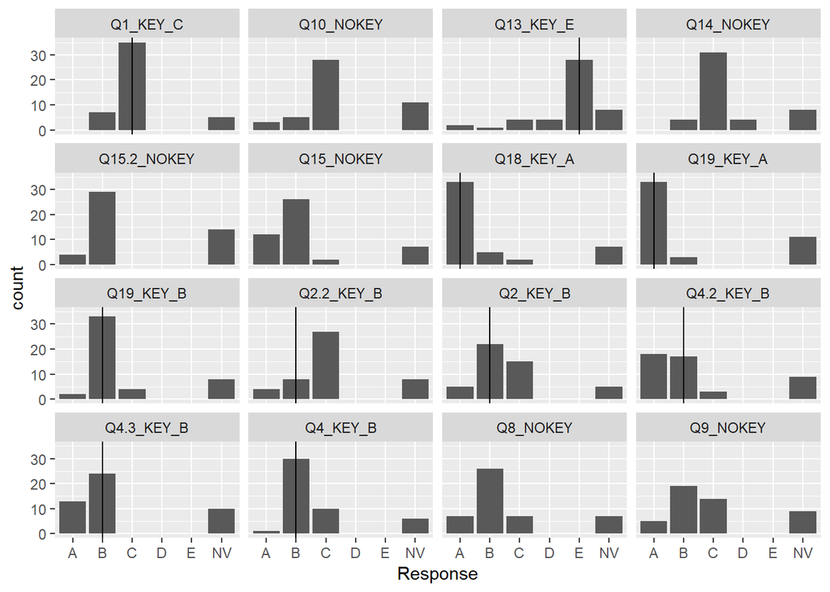

Additional Exploration:

Try to find percentages of the correct answer for each Question

```
##
##    Q1_KEY_C   Q10_NOKEY   Q13_KEY_E   Q14_NOKEY Q15.2_NOKEY   Q15_NOKEY
##          47          47          47          47          47          47
##   Q18_KEY_A   Q19_KEY_A   Q19_KEY_B  Q2.2_KEY_B    Q2_KEY_B  Q4.2_KEY_B
##          47          47          47          47          47          47
##  Q4.3_KEY_B    Q4_KEY_B    Q8_NOKEY    Q9_NOKEY
##          47          47          47          47
```

```
##
##   A   B   C   D   E  NV
## 142 259 182   8  28 133
```

```
## [1] 0.5595745
```

```
## [1] 0.7446809
```

```
## [1] 0.4680851
```

```
## [1] 0.1702128
```

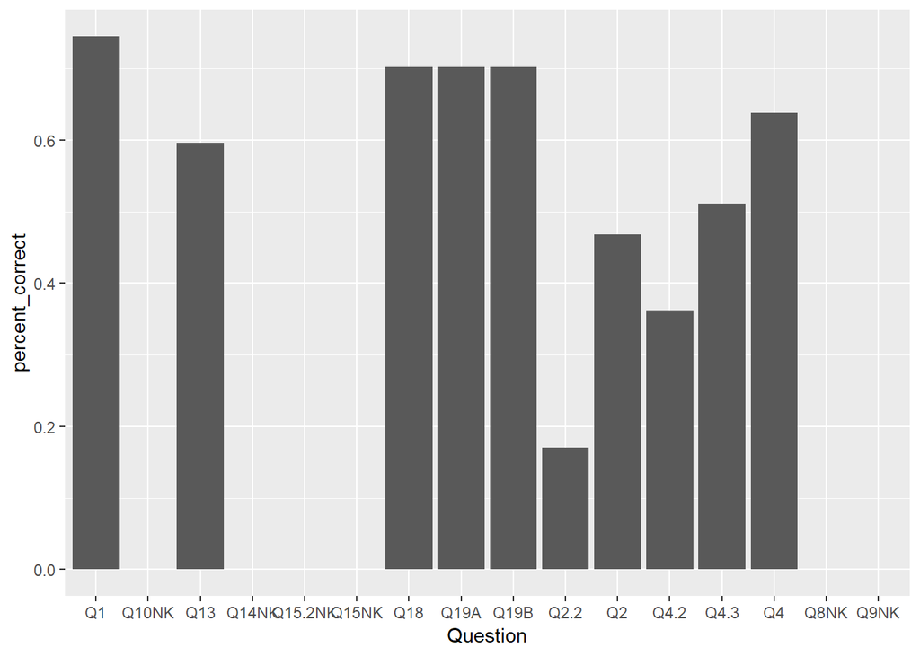

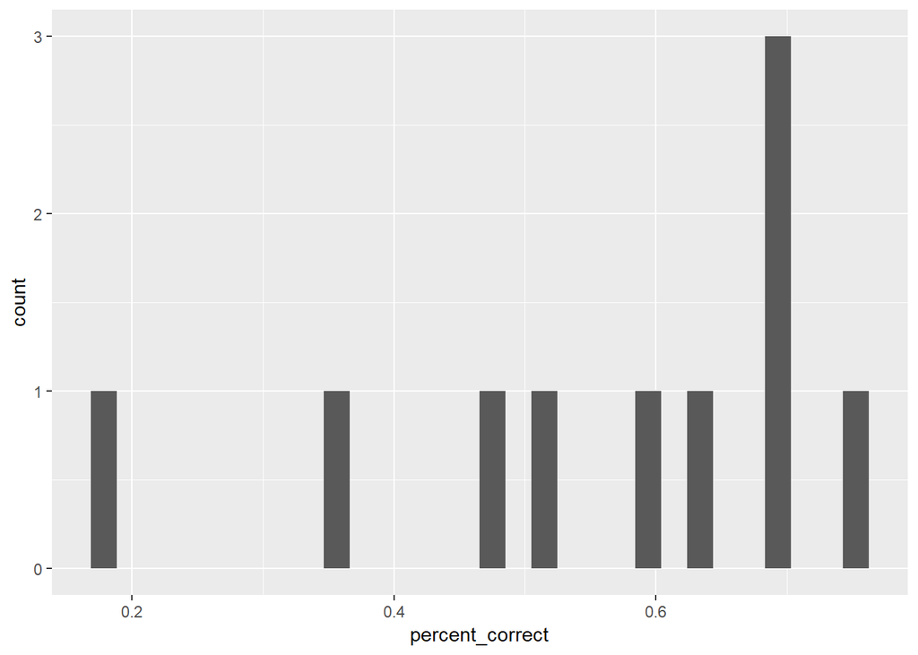

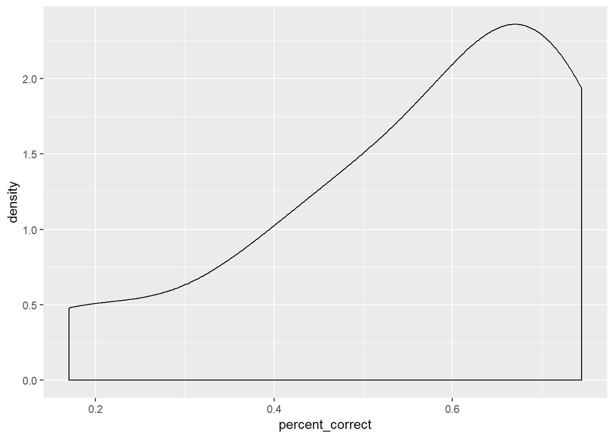

Analysis by Student:

Try to find percentages of the correct answer for each Student

```r
#Percent Correct Overall from Question Arrangement
mean(correct_vector == session2.1_tidy$Response, na.rm = TRUE)
```

```
## [1] 0.5595745
```

```r
correct_vector2 <- c(rep(c("C","B","B","B","B","B",NA,NA,NA,"E",NA,NA,NA,"A","A","B"),47))
session2.1_tidy_student <- session2.1_tidy %>% arrange(researchID)


#Percent Correct Overall from Student arrangement check YES
mean(correct_vector2 == session2.1_tidy_student$Response, na.rm = TRUE)
```

```
## [1] 0.5595745
```

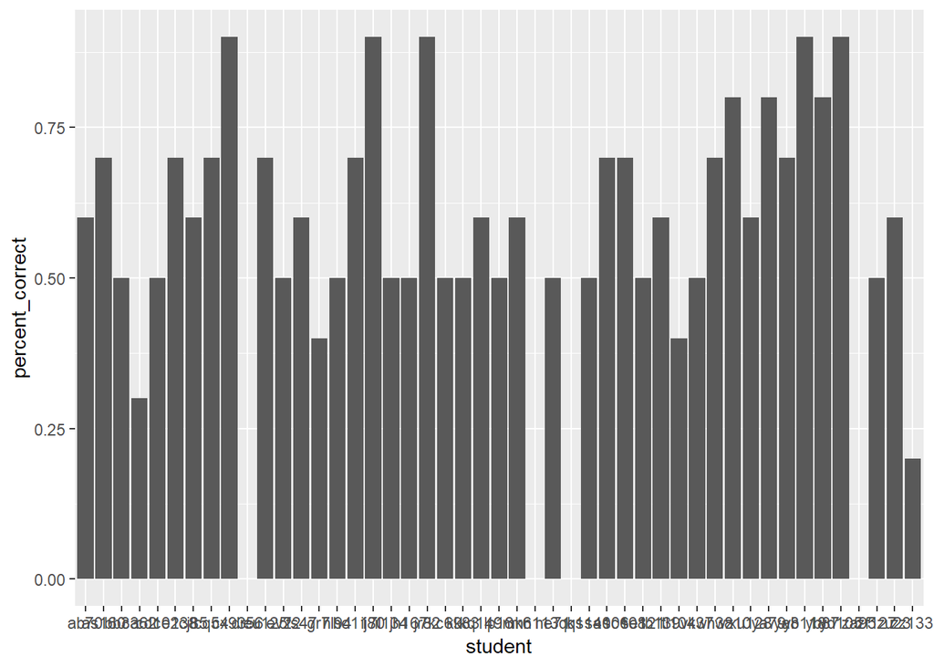

```r
#New Student every 16 rows, 47 students total


temp<- c()
for(i in seq(from = 16, to = 752,by = 16)){
  temp[i] <- round(mean((correct_vector2 == session2.1_tidy_student$Response)[(i-15):i],na.rm=TRUE), digits = 4)
}

percent_correct_student<-data.frame(percent_correct=c(rep(NA,47)),student=unique(session2.1_tidy_student$researchID))

percent_correct_student$percent_correct<- temp[c(which(!is.na(temp)), which(is.nan(temp)))[order(c(which(!is.na(temp)), which(is.nan(temp))))]]


#percent_correct_student is correct by checking the first student (correct_vector2 == session2.1_tidy_student$Response)[1:16]


#Bar plot revealing student level
ggplot(data = percent_correct_student, aes(x = student, y = percent_correct)) + geom_bar(stat='identity', position = position_dodge(width = 200))
```

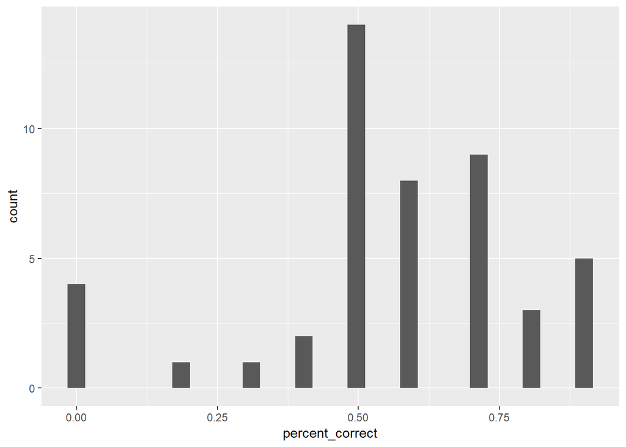

```r
#Histogram of Student Levels
ggplot(data = percent_correct_student, aes(x=percent_correct)) + geom_histogram()
```

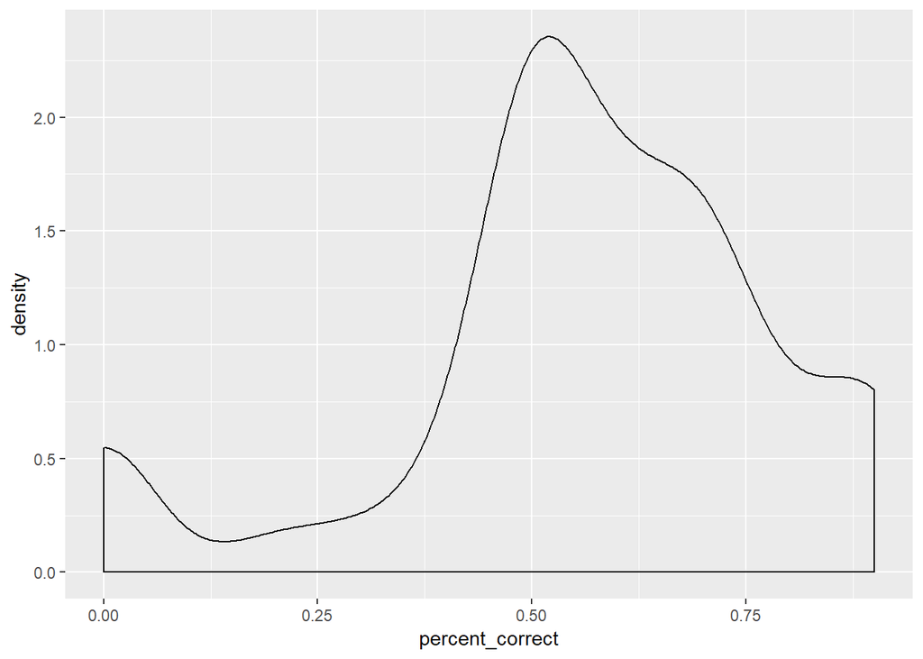

```r
#Density Plot of Student Levels
ggplot(data = percent_correct_student, aes(x=percent_correct)) + geom_density()
```